# Mass Shootings - The America Epidemic.

TUAN PHAM

2023-04-12

# Why is this subject?

- A controversial topic (Gun Violence)
- Provide an edge of the problems, a tip of the iceberg.
- Raise your insights about the problems, and then you can draw conclusions for yourself in order to protect you and your family.
- Recognize the primitive signs, not to live in skeptics but to enhance your awareness.

> *“If you look at the number of Americans killed since 9/11 by terrorism, it’s less than 100. If you look at the number been killed by gun violence, it’s in the tens of thousands.”*

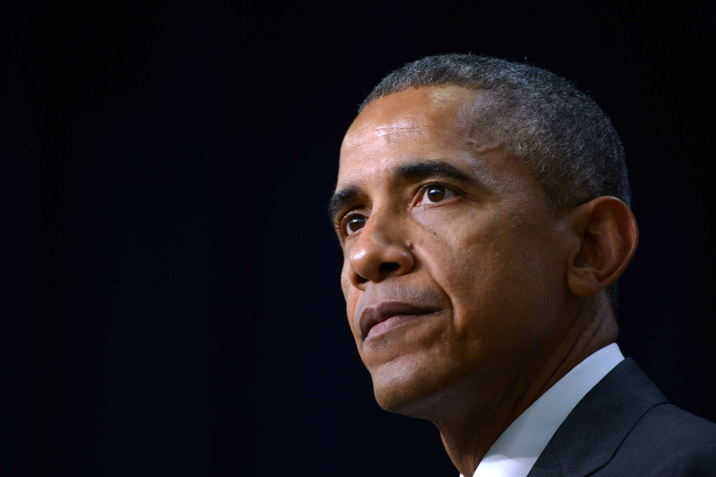

The 44th US President - Barack Obama

[Source: NBCNews](https://www.nbcnews.com/politics/white-house/obama-gun-control-im-frustrated-lack-common-sense-laws-n397646)

# DATA

`Words on my data set`

- **164 observations and 26 variables** from 1960 to 2023. (It was 143 observations and 25 variables originally from 1982 to 2022)
- My data set’s limitation:
  - Two data sets with two completely different structures.
  - Various manually plug-in data (15%)

# **Mother Jones**

  https://www.motherjones.com/politics/2012/12/mass-shootings-mother-jones-full-data/
- The data set’s authors are MARK FOLLMAN, GAVIN ARONSEN, and DEANNA PAN.
- The time span they collect is from 1982 to present, which included `originally 143 observations and 25 variables`. This is my work’s mainframe.

# **The Violence Project**

  https://www.theviolenceproject.org/
- No specific author’s names.
- The time span is from 1960 to 2022. This is the supplemental data for my main data frame.

# DATA (cont.)

```r
my_data <- read.csv('Mother Jones - Mass Shootings Database, 1982 - 2023 - Sheet1.csv', na.strings = "-")
my_data2 <- read.csv('Violence Project Mass Shooter Database - Version 6.1 - Full Database.csv', na.strings = "-")
```

- Both in form of `csv file`.

  > First set: familiar with what we have been learned so far.

  > Second set: highly complicated
- Missing data:

  > NA (Not Available) - Missing value

  > Unclear - The information has not been revealed by the authority.

  > TBD (To Be Determined) - The information has not been confirm yet.

# A Glimpse Over the Data

```r
glimpse(my_data)
```

```
## Rows: 164
## Columns: 26
## $ case                             <chr> "Louisville bank shooting", "Nashvill…
## $ city                             <chr> "Louisville", "Nashville", "East Lans…
## $ state                            <chr> "KY", "TN", "MI", "CA", "CA", "VA", "…
## $ date                             <chr> "4/10/2023", "3/27/2023", "2/13/2023"…
## $ summary                          <chr> "Connor Sturgeon, 25, opened fire ins…
## $ fatalities                       <int> 5, 6, 3, 7, 11, 6, 5, 3, 5, 3, 7, 3, …
## $ injured                          <int> 8, 6, 5, 1, 10, 6, 25, 2, 2, 2, 46, 0…
## $ total_victims                    <int> 13, 12, 8, 8, 21, 12, 30, 5, 7, 5, 53…
## $ location                         <chr> "workplace", "School", "School", "wor…
## $ age_of_shooter                   <int> 25, 28, 43, 67, 72, 31, 22, 22, 15, 2…
## $ prior_signs_mental_health_issues <chr> "Yes", NA, NA, NA, "Yes", NA, "Yes", …
## $ mental_health_details            <chr> NA, NA, NA, NA, "According to the LA …
## $ weapons_obtained_legally         <chr> "Yes", "Yes", "Yes", NA, NA, NA, NA, …
## $ where_obtained                   <chr> "gun dealership in Louisville", NA, N…
## $ weapon_type                      <chr> "Semiautomatic Rifle", "One Semiautom…
## $ weapon_details                   <chr> "AR-15 rifle", NA, NA, NA, NA, NA, NA…
## $ race                             <chr> "White", "White", "Black", "Asian", "…
## $ gender                           <chr> "M", "F (\"identifies as transgender\…
## $ sources                          <chr> "https://apnews.com/article/downtown-…
## $ mental_health_sources            <chr> NA, NA, NA, NA, "https://www.latimes.…
## $ sources_additional_age           <chr> NA, NA, NA, NA, NA, NA, NA, NA, NA, N…
## $ latitude                         <dbl> NA, NA, NA, NA, NA, 36.77262, 38.8809…
## $ longitude                        <dbl> NA, NA, NA, NA, NA, -76.25128, -104.7…
## $ type                             <chr> "Mass", "Mass", "Mass", "Spree", "Mas…
## $ year                             <int> 2023, 2023, 2023, 2023, 2023, 2022, 2…
## $ day_of_week                      <chr> "Monday", "Monday", "Monday", "Monday…
```

# Data Key Terms

**Case**: Case’s name well-known by the media

**City/State**: Location where the incidents happened

**Date/Year/Date of Week**: Specific day and year when the incidents occurred

**Summary**: Summary about the case

**Fatalities/Injured/Total Victims**: Facts that stand out from the incident

**Location**: Type of location where the incidents occurred

**Age of Shooter/Race/Gender/Prior Sign Mental Issues**: The shooter profile

**Weapons Obtained Legally/Where Obtained/Weapons Type/Weapons Details**: Weapons profile

**Sources/Mental Health Sources/Additional Age Source**: All sources that were used to conduct this data set.

**Longitude/Latitude**: GPS coordination of the incident’s location

**Type**: Mass Shooting or Shooting Spree designated to the incident

# Packages

- The tidyverse.
- Data wrangling and plots.

```r
#install.packages(tidyverse)
library(dplyr)
library(tidyverse)
```

# Data Wrangling

```r
# Assign the variables to the data type of my choice.
 my_data$age_of_shooter <- as.integer(my_data$age_of_shooter)
 my_data$fatalities <- as.integer(my_data$fatalities)
 my_data$injured <- as.integer(my_data$injured)
 my_data$total_victims <- as.integer(my_data$total_victims)
 my_data$latitude <- as.numeric(my_data$latitude)
 my_data$longitude <- as.numeric(my_data$longitude)
```

```r
# remove newline
my_data$location <- str_replace_all(my_data$location,'[\r\n]','')
my_data$race <- str_replace_all(my_data$race,'[\r\n]','')


# replace a string by another one
my_data$location[my_data$location == 'religious' | my_data$location == 'Religious'] <- 'Religious Place'
my_data$location[my_data$location == 'workplace'] <- 'Workplace'

my_data$race[my_data$race == 'unclear'] <- 'Unclear'
my_data$race[my_data$race == 'black'] <- 'Black'
my_data$race[my_data$race == 'white'] <- 'White'

my_data$gender[2] <- 'Trans'
my_data$gender[my_data$gender == 'M'] <- 'Male'
my_data$gender[my_data$gender == 'F'] <- 'Female'
```

# What’s The Mass Shooting?

> The FBI defines a “mass shooting” as any incidents in which at least four people are murdered with a gun.

[Source: DOJ](https://www.ojp.gov/ncjrs/virtual-library/abstracts/analysis-recent-mass-shootings)

# What questions should be raised?

> Will the time frame would say anything about the incidents `in general`?

> Would the `age, race, and gender` give any insights about the shooter’s profile?

> What would stand out if we cross `the shooter with prior mental health issues` out of the equation?

> Where are the `locations` that the incidents likely take place?

> What `types of weapons` do the assailants’ likely use?

> What conclusion about the `age of shooter`, `race` and `prior mental health issues` could we draw out?

> What is interesting about the connection between `age of the shooter` over `year`?

> Will `gender` play any roles in corresponding to `age of the shooter`?

> How have the incidents distributed `across the America`?

# A First Glance about the Incidents over Years

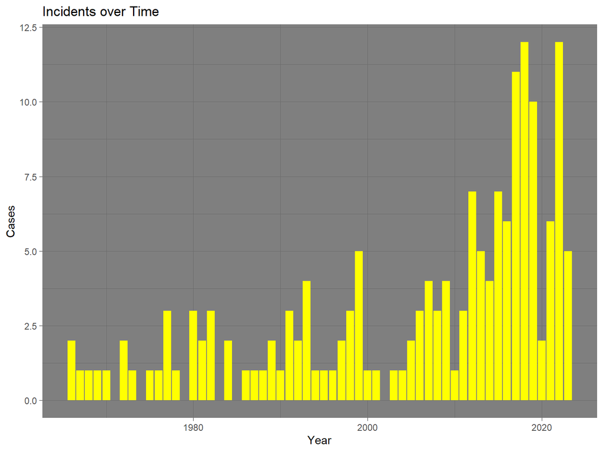

# Data Summary

```
##  age_of_shooter   fatalities      injured       total_victims
##  Min.   :11.0   Min.   : 3.0   Min.   :  0.00   Min.   :  3.00
##  1st Qu.:23.0   1st Qu.: 4.0   1st Qu.:  1.00   1st Qu.:  6.00
##  Median :32.0   Median : 6.0   Median :  3.00   Median : 10.00
##  Mean   :33.9   Mean   : 7.5   Mean   : 10.56   Mean   : 18.09
##  3rd Qu.:43.0   3rd Qu.: 8.0   3rd Qu.:  9.50   3rd Qu.: 16.00
##  Max.   :72.0   Max.   :58.0   Max.   :546.00   Max.   :604.00
##                                NA's   :1        NA's   :1
```

**Las Vegas Strip Massacre**: 604 victims

```
##                       Case Fatality Injured Victims      City State      Date
## 1 Las Vegas Strip massacre       58     546     604 Las Vegas    NV 10/1/2017
##   Age  Race Gender
## 1  64 White   Male
##                                                                                                                    Weapons
## 1 23 firearms, mostly rifles; including scopes, and two modified for "fully automatic" firing; two were mounted on tripods
```

**LA Dance Studio Mass Shooting**: Oldest age for a mass shooter

**West Middle School Killings**: Youngest age

```
##                              Case Age Fatality Injured Victims          City
## 1   LA dance studio mass shooting  72       11      10      21 Monterey Park
## 2 Westside Middle School killings  11        5      10      15     Jonesboro
##   State      Date  Race Gender
## 1    CA 1/21/2023 Asian   Male
## 2    AR 3/24/1998 White   Male
##                                                                      Weapons
## 1                                                      Semiautomatic Handgun
## 2 Two Rifles, Two Semiautomatic Handguns, Three Revolvers and Two Derringers
```

- Those are the outliers for each of the variables that they represent.

# Who are they?

### The Whole Picture

```
## # A tibble: 8 × 3
##   race            Total Ratio
##   <chr>           <int> <dbl>
## 1 White              96 58.5
## 2 Black              29 17.7
## 3 Latino             13  7.93
## 4 Asian              11  6.71
## 5 Other               8  4.88
## 6 Native American     3  1.83
## 7 Unclear             2  1.22
## 8 <NA>                2  1.22
```

### Before 2002

```
## # A tibble: 5 × 3
##   race    Count Ratio
##   <chr>   <int> <dbl>
## 1 White      39 70.9
## 2 Black      10 18.2
## 3 Asian       3  5.45
## 4 Latino      2  3.64
## 5 Unclear     1  1.82
```

### After 2002

```
## # A tibble: 8 × 3
##   race            Count  Ratio
##   <chr>           <int>  <dbl>
## 1 White              57 52.3
## 2 Black              19 17.4
## 3 Latino             11 10.1
## 4 Asian               8  7.34
## 5 Other               8  7.34
## 6 Native American     3  2.75
## 7 <NA>                2  1.83
## 8 Unclear             1  0.917
```

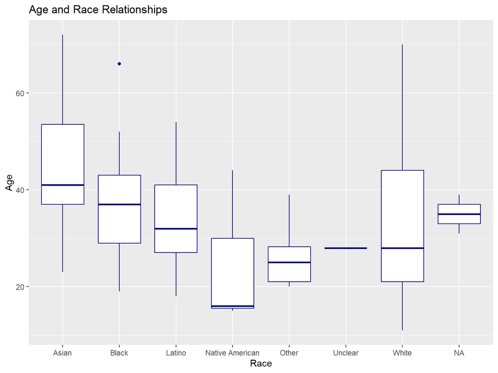

The Average Age of the Shooters among Races

| Race | Average Age of the Shooters |
| --- | --- |
| White | ~ 28-29 years old |
| Latino | ~ 32-33 years old |
| Black | ~ 38-39 years old |
| Asian | ~ 41 years old |
| Native Am. | ~ 18 years old |

# Where Do The Mass Shootings Likely Occur?

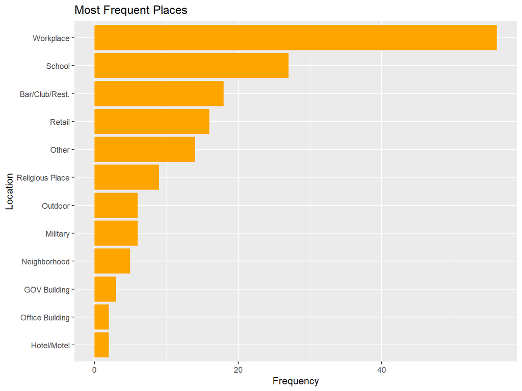

| Location | Frequency |
| --- | --- |
| Workplace | ~ 34% |
| School | ~ 16% |
| Bar/Club/Rest. | ~ 11% |
| Retail | ~ 10% |
| Other | ~ 9% |
| Religious Place | ~ 6% |

There is information’s limitation about the observations in `location` variable in the raw data. - Most of the Nightlife observations like Bar/Club/Restaurants was classified as `Other`, which make the original data had a big chunk of number in ‘Other’ category.

# What Weapons Were Likely Used by The Assailants?

```
## # A tibble: 9 × 3
##   `Weapon Types`                                        Percentage Count
##   <chr>                                                      <dbl> <int>
## 1 Semiautomatic Handgun                                      24.4     40
## 2 Semiautomatic Rifle                                        11.0     18
## 3 One Semiautomatic Rifle and One Semiautomatic Handgun       7.32    12
## 4 Handgun                                                     6.71    11
## 5 Rifle                                                       4.88     8
## 6 Assault Rifle                                               3.66     6
## 7 Two Semiautomatic Handguns                                  3.66     6
## 8 Two Handguns                                                3.05     5
## 9 One Semiautomatic Handgun and One Revolver                  2.44     4
```

| Firearm | Percent of Carrying |
| --- | --- |
| Semi-Auto Handgun | ~ 41% |
| Semi-Auto Rifle | ~ 20% |
| Handgun(Old Versions) | ~ 6.7% |
| Rifle(Old Version) | ~ 5% |
| Assault Rifle | ~ 5% |
| Shotgun | ~ 4% |

- The preferred weapons was used by the mass shooter are Semi-Auto Handgun, Semi-Auto Rifle or both of them.
- Light weight, high bullet rate, big magazines. It could help them cause mass casualties in a short period of time.

# Race and Mental Health Issues

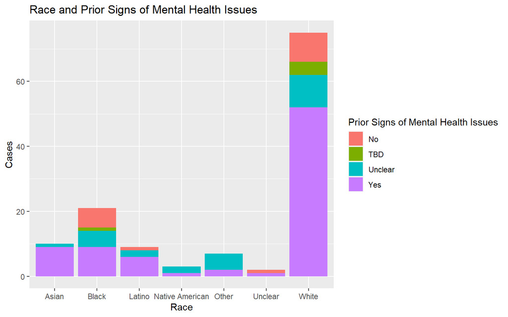

| Race | Prior Mental Health Issues |
| --- | --- |
| Asian | 90% |
| White | 69% |
| Latino | 67% |
| Black | 43% |

# Will The Shooter’s Age Be Related over Time?

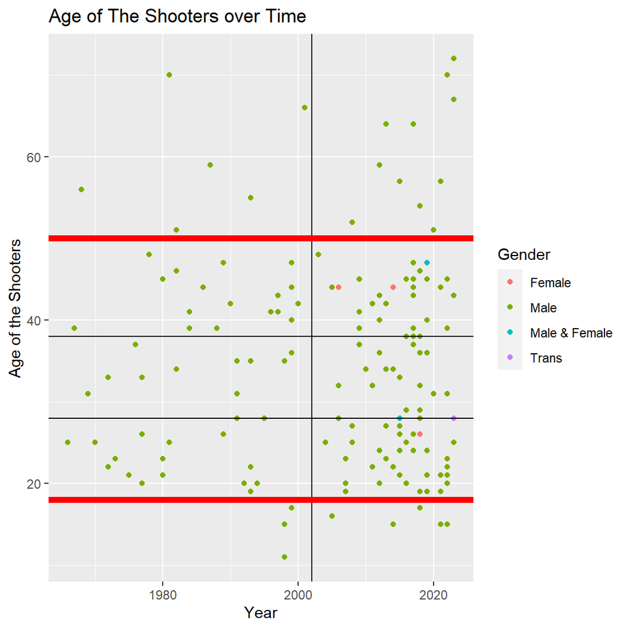

# With Prior Mental Health Issues Plot

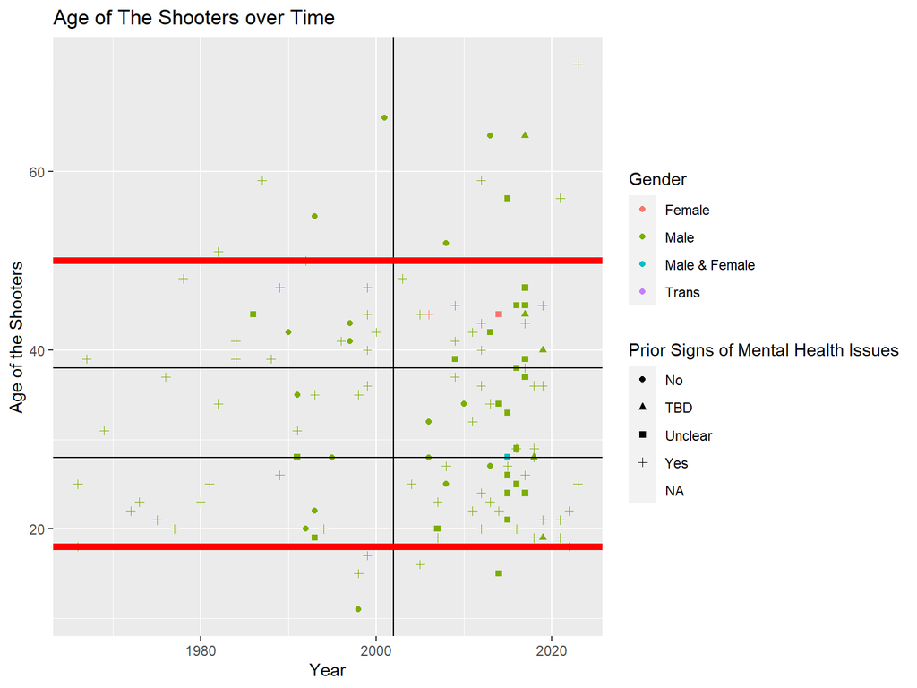

The incidents in which the shooter had prior mental health issues have plotted as the plus sign (+) on the plot above.

# Without Prior Mental Health Issues Plot

Now we take it off the plot to see how the original plot look like.

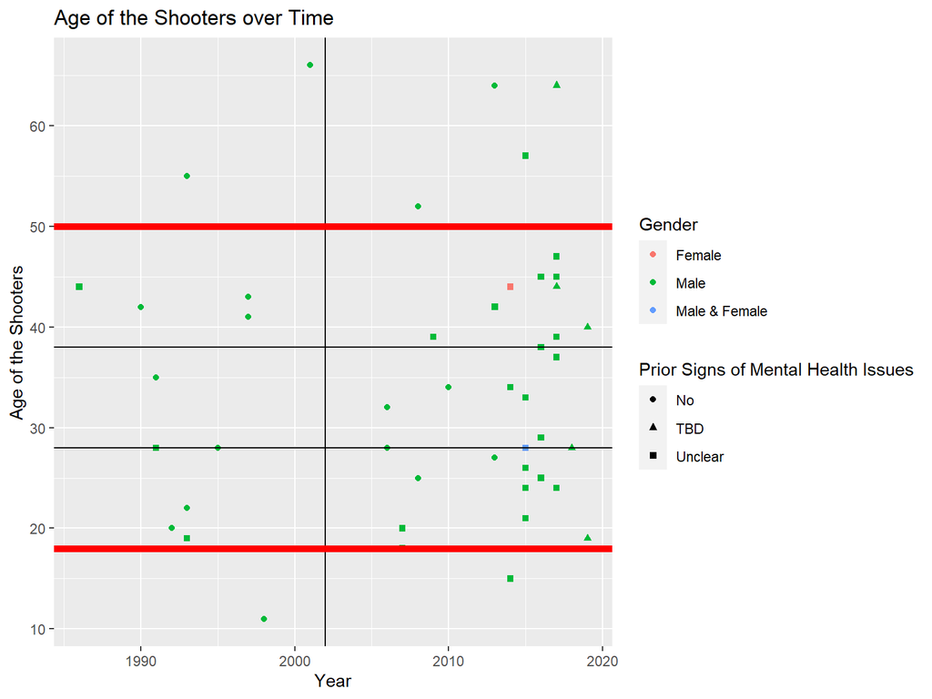

Compare to the original plot, we can see intuitively the dots’ density was reduced significantly. Hence, we are going to find the difference between with and without prior mental health issues by numbers.

# Realize Intuitive Consideration by Numbers

```r
my_data %>%
  filter(prior_signs_mental_health_issues == "Yes") %>%
  group_by(year) %>%
  nrow()
```

```
## [1] 80
```

If we filter out the cases with the prior mental health issues, there are eighty cases was off the chart, which is almost half cases of mass shooting in the US since 1960.

```r
my_data %>%
  filter(weapons_obtained_legally == "No") %>%
  group_by(year) %>%
  nrow()
```

```
## [1] 16
```

In a different case, I cross off the legal weapons obtained, only 16 cases was off the chart, which roughly 10% of all of the cases.

# Conclusion:

Background check on Mental Health Issues is crucial.

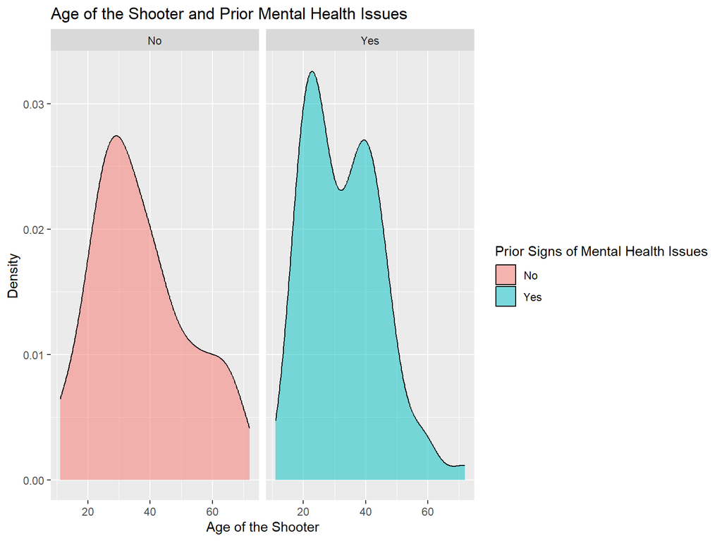

| Prior Signs of Mental Health Issues | Age of the Shooter |
| --- | --- |
| Yes | around 23 and 40 |
| No | around 30 |

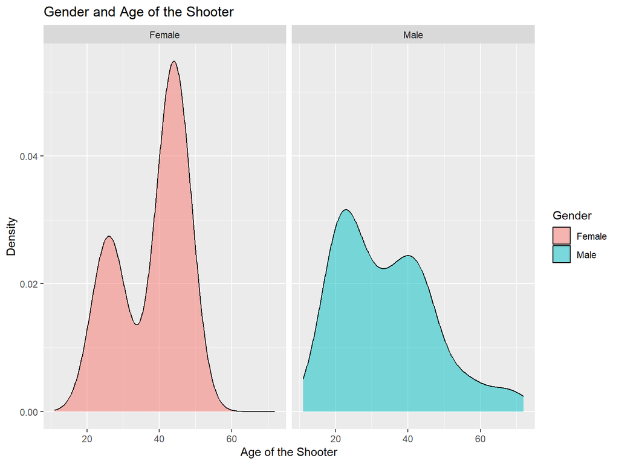

| Gender | Most Likely |
| --- | --- |
| Male | Early 20’s to Mid 40’s |
| Female | Mid 20’s or Mid 40’s |

```
## # A tibble: 4 × 3
##   gender        Count Percentage
##   <chr>         <int>      <dbl>
## 1 Male            158     96.3
## 2 Female            3      1.83
## 3 Male & Female     2      1.22
## 4 Trans             1      0.610
```

[output not shown]

# Geography Graph of The Events

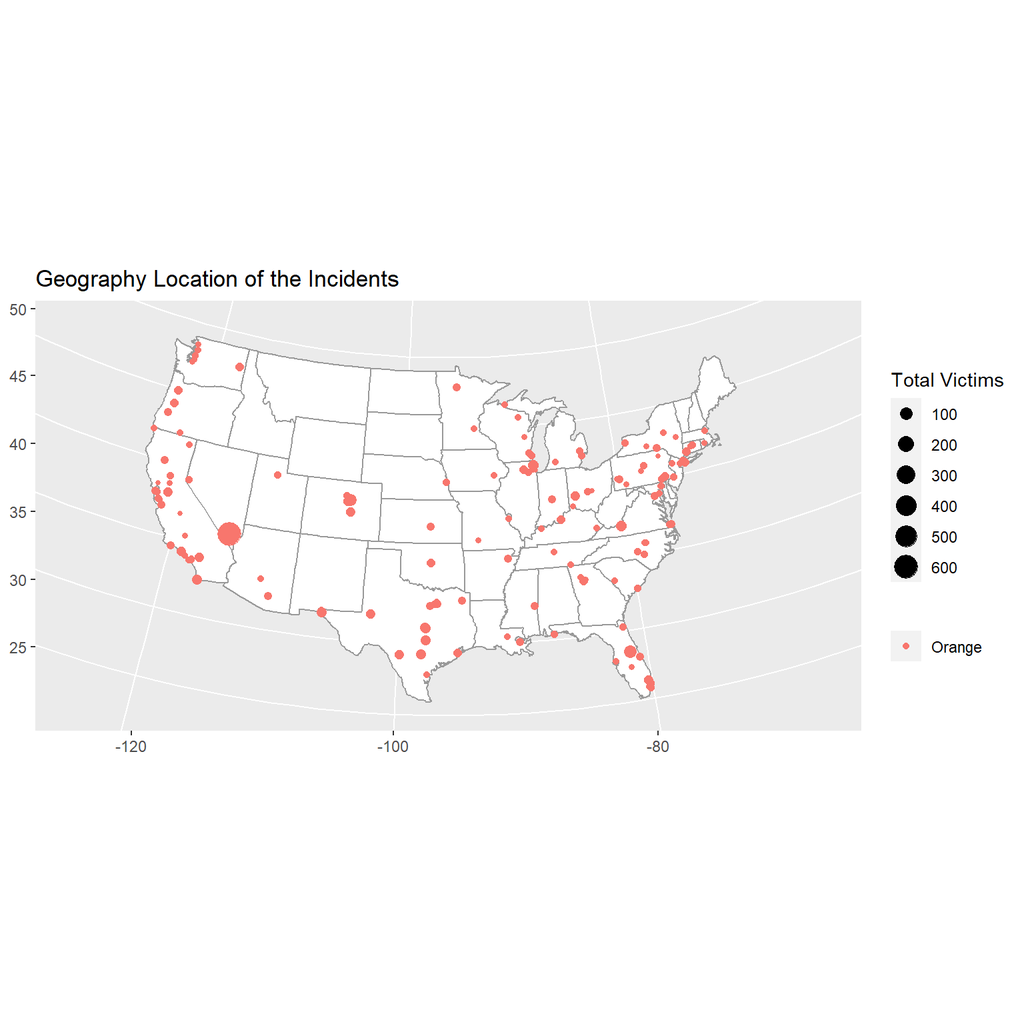

The graph shows us an idea that the incidents most likely occurs over the East and West side of the country, and the Mid-west is least likely to happen the mass shootings.

```
## # A tibble: 40 × 3
##    state Cases Percentage
##    <chr> <int>      <dbl>
##  1 CA       28      17.1
##  2 TX       16       9.76
##  3 FL       12       7.32
##  4 PA        8       4.88
##  5 CO        7       4.27
##  6 NY        7       4.27
##  7 WA        7       4.27
##  8 IL        5       3.05
##  9 MI        5       3.05
## 10 WI        5       3.05
## # ℹ 30 more rows
```

Colorado is the state in top 5 rating of mass shooting even the population rank is not in top 20 nationwide.

Massachusetts surprisingly has no records on mass shooting even the population is in top 16 nationwide.

[figure not shown]

State Population Source

# Pick Your Day to Go Out.

```
## # A tibble: 7 × 3
##   day_of_week Count Percentage
##   <chr>       <int>      <dbl>
## 1 Monday         30      18.3
## 2 Thursday       29      17.7
## 3 Friday         26      15.9
## 4 Wednesday      25      15.2
## 5 Sunday         20      12.2
## 6 Tuesday        19      11.6
## 7 Saturday       15       9.15
```

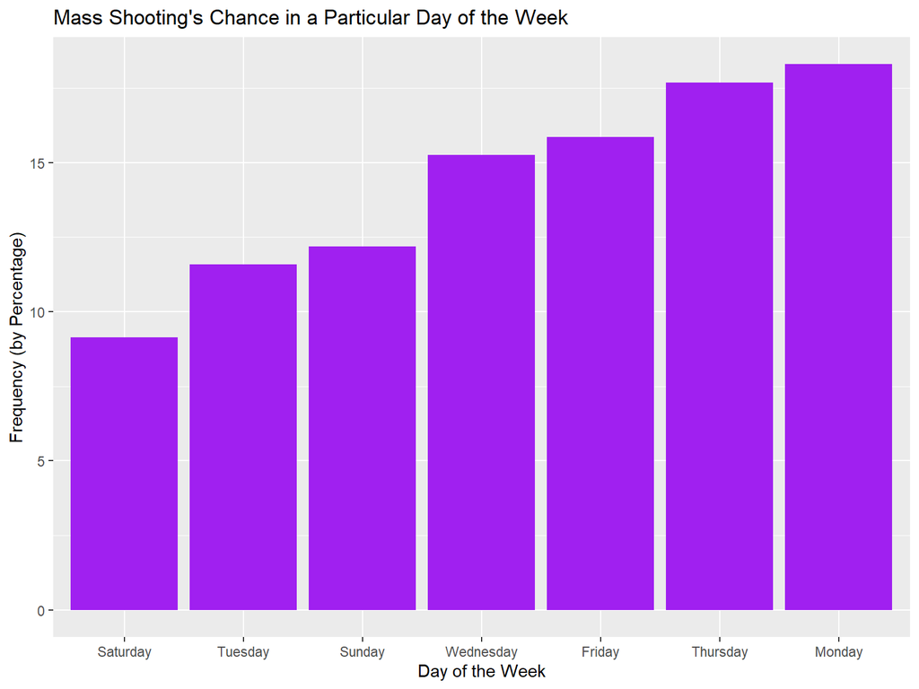

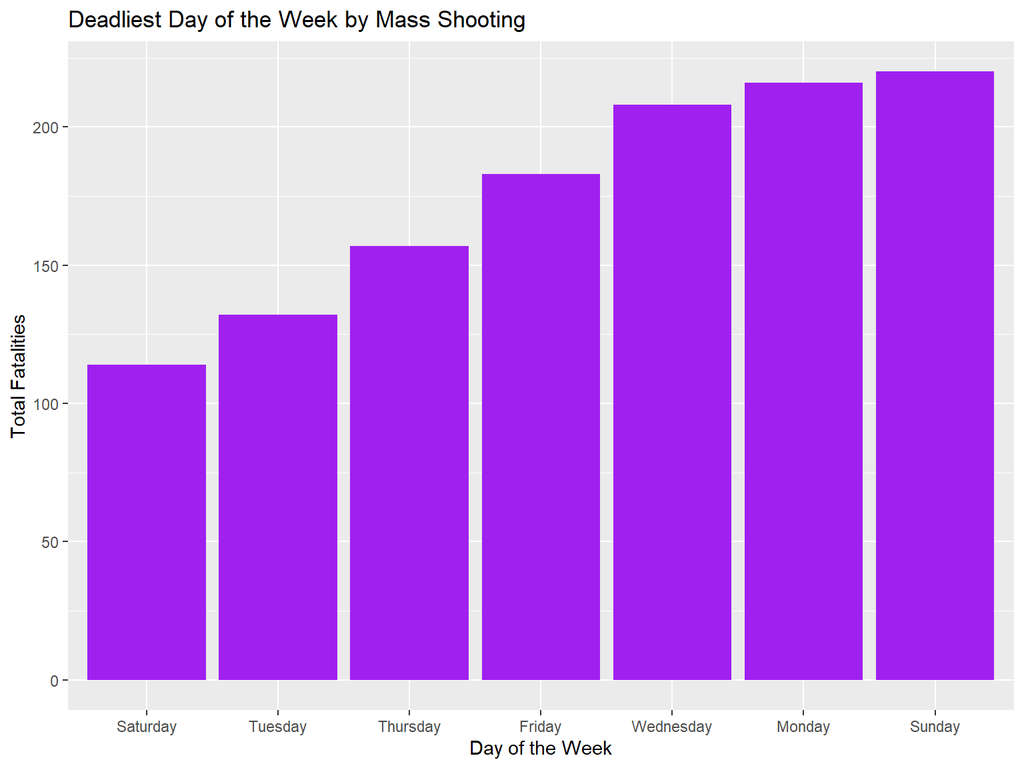

Sunday is the deadliest day of the week in term of Mass Shooting but Monday is the most likely day for the Mass Shooter plan to act.